# 03｜房價資料探索與切分

第二週主線上半；對應 `02_端到端機器學習專案.md` 的問題定義、取樣、EDA 與特徵組合。課堂操作約 25 分鐘。目標：先保留 test，再以 training data 提出特徵假設。

## 來源與改編界線

- [ageron/handson-mlp / 02_end_to_end_machine_learning_project.ipynb](https://github.com/ageron/handson-mlp/blob/47eba45aacc85feae51ba7db68dd1ca66cb25e0a/02_end_to_end_machine_learning_project.ipynb)：儲存格 11 載入資料、24–40 切分與分層、45–58 地理圖／相關／特徵組合

**本課程修改／補充：** 改用已驗證本機 CSV；明列切分索引，新增穩定 ID 哈希的最小示例。保留原始 20,640 筆的完整訓練／測試切分；本檔不建立預測模型，也不檢視 test 的房價標籤。

來源固定至上述 commit；原檔保留於 `../upstream/`，逐檔 SHA-256 見 `../upstream/manifest.json`。Géron 程式依 Apache-2.0 改編，授權原文保留。儲存格索引從 0 起算。圖表與數值是本 Notebook 重跑結果，不能直接當成書中成效。

從第一格依序執行；各本可獨立重跑。Python 環境與資料準備見 操作說明。

```python
import numpy as np
import pandas as pd
import matplotlib.pyplot as plt
from mlcourse.common import ROOT, DATA, OUT, SEED, FAST, setup, savefig, report, data_path
setup()
```

```
{'profile': 'fast',
 'seed': 42,
 'data': '/Users/leonjye/Documents/MacProject/MLCourse2026/programs/data'}
```

## 1. 問題定義與資料字典

以地理區域的 8 個數值特徵與 `ocean_proximity` 類別特徵預測 `median_house_value`（美元）。一列是一個區域，不能解讀成單一房屋價格。資料是歷史快照，房價存在封頂；不能直接用於今日估價。

主指標 RMSE：較強懲罰大誤差；輔助 MAE：提供另一種誤差尺度。假設部署的取樣單位／年代與開發資料一致；若預測新地區或未來年代，應再設地區／時間驗證。

```python
from mlcourse.common import housing_split
from sklearn.model_selection import train_test_split
train,test=housing_split()
assert len(train)==16512 and len(test)==4128
print('Training rows:',len(train),'Locked test rows:',len(test))
print('Input columns:',len(train.columns)-1)
train.head()
```

```
Training rows: 16512 Locked test rows: 4128
Input columns: 9
```

|  | longitude | latitude | housing_median_age | total_rooms | total_bedrooms | population | households | median_income | median_house_value | ocean_proximity |
| --- | --- | --- | --- | --- | --- | --- | --- | --- | --- | --- |
| 13096 | -122.42 | 37.80 | 52.0 | 3321.0 | 1115.0 | 1576.0 | 1034.0 | 2.0987 | 458300.0 | NEAR BAY |
| 14973 | -118.38 | 34.14 | 40.0 | 1965.0 | 354.0 | 666.0 | 357.0 | 6.0876 | 483800.0 | <1H OCEAN |
| 3785 | -121.98 | 38.36 | 33.0 | 1083.0 | 217.0 | 562.0 | 203.0 | 2.4330 | 101700.0 | INLAND |
| 14689 | -117.11 | 33.75 | 17.0 | 4174.0 | 851.0 | 1845.0 | 780.0 | 2.2618 | 96100.0 | INLAND |
| 20507 | -118.15 | 33.77 | 36.0 | 4366.0 | 1211.0 | 1912.0 | 1172.0 | 3.5292 | 361800.0 | NEAR OCEAN |

```python
summary=pd.DataFrame({'dtype':train.dtypes.astype(str),'missing_train':train.isna().sum(),
                      'unique_train':train.nunique()})
summary
```

|  | dtype | missing_train | unique_train |
| --- | --- | --- | --- |
| longitude | float64 | 0 | 817 |
| latitude | float64 | 0 | 835 |
| housing_median_age | float64 | 0 | 52 |
| total_rooms | float64 | 0 | 5473 |
| total_bedrooms | float64 | 168 | 1827 |
| population | float64 | 0 | 3640 |
| households | float64 | 0 | 1712 |
| median_income | float64 | 0 | 10930 |
| median_house_value | float64 | 0 | 3674 |
| ocean_proximity | object | 0 | 5 |

## 2. 依收入階層分層

下表只比較收入特徵的比例；取樣時可依事先指定的特徵分層。收入階層只用於取樣，不加入模型。不同 seed 的單次隨機切分可能碰巧很好；不能由一次結果宣稱分層永遠改善預測。

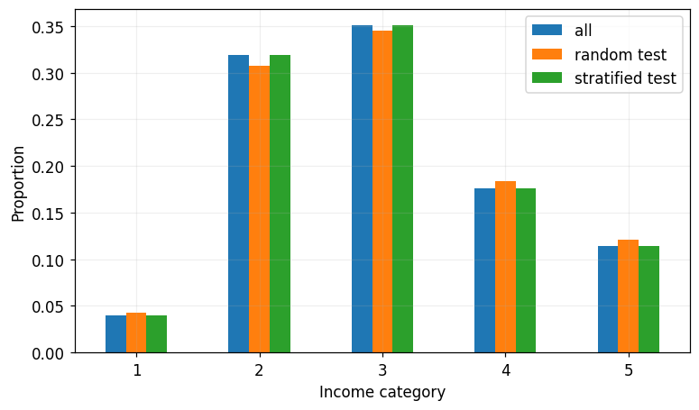

| median_income | all | random test | stratified test | random_error_pct | stratified_error_pct |
| --- | --- | --- | --- | --- | --- |
| 1 | 0.039826 | 0.042393 | 0.039971 | 6.447689 | 0.364964 |
| 2 | 0.318847 | 0.307413 | 0.318798 | -3.586081 | -0.015195 |
| 3 | 0.350581 | 0.345203 | 0.350533 | -1.533997 | -0.013820 |
| 4 | 0.176308 | 0.184109 | 0.176357 | 4.424292 | 0.027480 |
| 5 | 0.114438 | 0.120882 | 0.114341 | 5.630821 | -0.084674 |

```python
frame=pd.concat([train,test]).sort_index()
def income_cat(df):
    return pd.cut(df.median_income,[0,1.5,3,4.5,6,np.inf],labels=[1,2,3,4,5])
random_train,random_test=train_test_split(frame,test_size=.2,random_state=SEED)
proportions=pd.DataFrame({name:income_cat(df).value_counts(normalize=True).sort_index()
    for name,df in [('all',frame),('random test',random_test),('stratified test',test)]})
proportions.plot.bar();plt.ylabel('Proportion');plt.xlabel('Income category');plt.xticks(rotation=0)
savefig('03_stratified_sampling')
proportions.assign(random_error_pct=100*(proportions['random test']/proportions['all']-1),
                   stratified_error_pct=100*(proportions['stratified test']/proportions['all']-1))
```

## 3. 只對 training data 做 EDA

位置、收入與房價的共同變化能提出假設，不能識別因果。此處無外部底圖；散點經緯度直接來自資料。

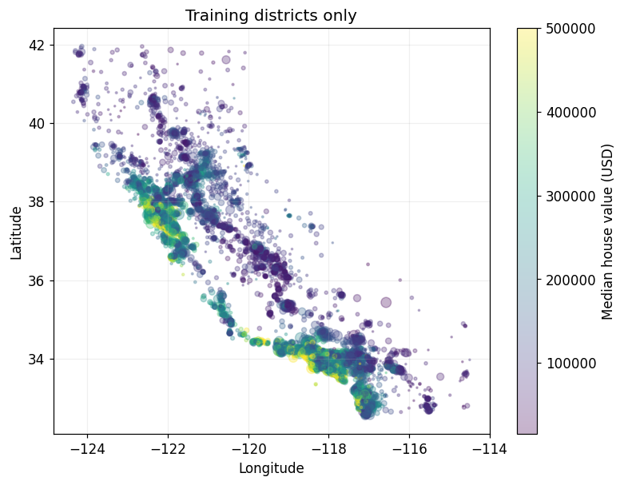

```python
fig,ax=plt.subplots(figsize=(8,6))
points=ax.scatter(train.longitude,train.latitude,s=np.clip(train.population/100,2,80),
                  c=train.median_house_value,cmap='viridis',alpha=.3)
fig.colorbar(points,ax=ax,label='Median house value (USD)')
ax.set(xlabel='Longitude',ylabel='Latitude',title='Training districts only')
savefig('03_housing_geography')
```

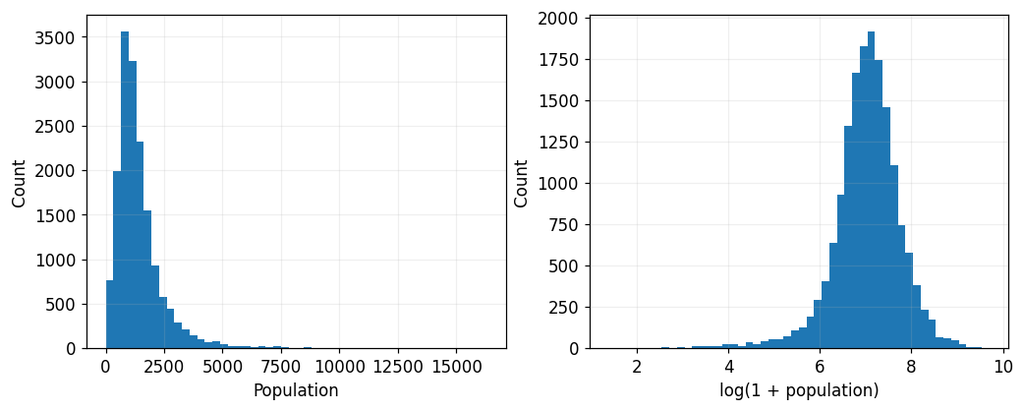

```
Training targets at/above 500001: 764
```

```python
fig,axes=plt.subplots(1,2,figsize=(11,4))
axes[0].hist(train.population,bins=50);axes[0].set(xlabel='Population',ylabel='Count')
axes[1].hist(np.log1p(train.population),bins=50);axes[1].set(xlabel='log(1 + population)',ylabel='Count')
savefig('03_long_tail')
print('Training targets at/above 500001:',int((train.median_house_value>=500001).sum()))
```

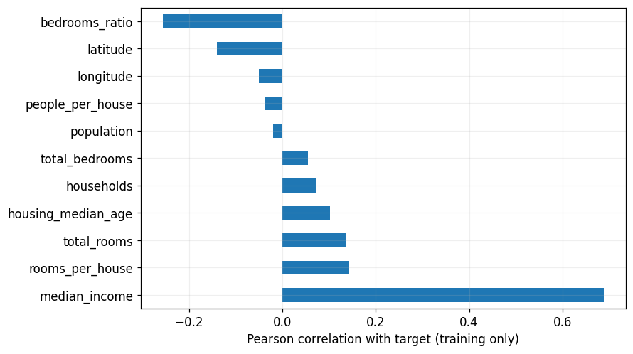

```
median_house_value    1.000000
median_income         0.688380
rooms_per_house       0.143663
total_rooms           0.137455
housing_median_age    0.102175
households            0.071426
total_bedrooms        0.054635
population           -0.020153
people_per_house     -0.038224
longitude            -0.050859
latitude             -0.139584
bedrooms_ratio       -0.256397
Name: median_house_value, dtype: float64
```

```python
eda=train.copy()
eda['rooms_per_house']=eda.total_rooms/eda.households
eda['bedrooms_ratio']=eda.total_bedrooms/eda.total_rooms
eda['people_per_house']=eda.population/eda.households
corr=eda.select_dtypes('number').corr()['median_house_value'].sort_values(ascending=False)
corr.drop('median_house_value').plot.barh(figsize=(8,5))
plt.xlabel('Pearson correlation with target (training only)');savefig('03_feature_correlations')
corr
```

**注意：** 這裡加入特徵是為了探索；正式模型會把相同計算放回 Pipeline。Pearson 相關低不代表沒有非線性關係。房價封頂影響誤差解讀；不要在觀察 test 後自行刪掉難預測的樣本。

## 4. 選做：固定 seed 為何還不夠？

此為自編穩定 ID 示意。使用 SHA-256 的前 64 位元作決定，不用 Python `hash()`（可能因程序而改變）。ID 必須永久且唯一；以下 `district-0001` 為合成 ID，不宣稱房價資料已有業務 ID。哈希比例是期望值，不保證恰好 20%，也不保證分層或群組隔離。

```python
import hashlib
def in_test(identifier,ratio=.2):
    value=int.from_bytes(hashlib.sha256(str(identifier).encode()).digest()[:8],'big')
    return value < ratio*2**64
ids=pd.Series([f'district-{i:04d}' for i in range(1000)])
original=set(ids[ids.map(in_test)])
reordered=ids.sample(frac=1,random_state=SEED)
extended=pd.concat([reordered,pd.Series(['district-new-1','district-new-2'])],ignore_index=True)
new_members=set(extended[extended.map(in_test)])
assert original == new_members.intersection(set(ids))
_,r1=train_test_split(ids.to_numpy(),test_size=.2,random_state=SEED)
_,r2=train_test_split(reordered.to_numpy(),test_size=.2,random_state=SEED)
print('Hash test members:',len(original),'same after reorder + append:',True)
print('Random split members changed by reordering:',len(set(r1)^set(r2)))
report('housing_split',{'train_rows':len(train),'test_rows':len(test),'overlap':len(set(train.index)&set(test.index)),
                        'hash_stable':True,'hash_test_rows':len(original)})
```

```
Hash test members: 216 same after reorder + append: True
Random split members changed by reordering: 334
```

## 練習

1. 哪些欄位的缺失需要填補？**`total_bedrooms`；以實際表格為準。**
2. 取樣用收入分層，是否已解決未來房價漂移？**沒有，時間／地區代表性仍需另外檢查。**
3. 若地理鄰近區域高度相似，隨機 CV 能代表新城市嗎？**未必；可用地理群組驗證，見 08 的群組與時間示例。**

下一本從相同固定切分重新開始，可單獨執行。